# Introduction to Git and GitHub

Mahek Shah

2024-06-20

> ❗️CCR doesn’t support the use of Git or GitHub due to firewall issues.

# 1 Introduction to Git and GitHub

## 1.1 What is Git?

- Git is an opensource version control system designed to handle small or large projects. It is usually used by programmers to develop softwares collaboratively while controlling for the source code.
- It is usually implemented using a set of command line tools.

### 1.1.1 Why use version control?

- It provides a framework for collaborating.
- Allows to track changes to files over time!
- Also, allows to restore previous versions of a file.

## 1.2 GitHub

- It is one of the many websites which can host your repositories using Git.

# 2 Working with GitHub

## 2.1 Github terminology

**1. Repository = Directory**  
- This refers to any directory managed by Git.  
- There can be multiple copies of a repository at different locations.  
- Files in a repository are tracked by Git which means that they are under version control.

**2. Commits = Revision** - These are snapshots which record the current state of a tracked file in a repository.  
- Commits usually are accompanied with a brief message describing the changes made.  
- Make the commit message informative!

[figure not shown]

Source: https://xkcd.com/1296/

**3. Fork = Personal copy of someone else’s repository**  
- This allows you to use and modify someone else’s code without affecting the original repository.  
- The forked repository is still connected to the original repository. Any changes in the original repository can be synced.

> When forking a repository, it will have the same accessibility setting as the original repo. E.g.; forking a private repo will make a private fork, making it public will severe the connection!

**4. Push = Update committed changes to the remote repository on GitHub.com**  
- Locally made changes can be committed and pushed to an online repository.  
- This can allow others to access these changes.

**5. Pull = Update your local copy with changes made to the remote repository.**  
- This is especially helpful when you are working collaboratively on a project.  
- Also used when you’ve forked a repository and changes are made to the original repository.

**6. Branch = Parallel but different version of a repository.**  
- Changes in made in the branch don’t affect the files in the main/primary branch.

**7. Merge = Allows the changes in one branch to be synced with another branch.**  
- After making changes to a branch, the changes can be merged with the main or any other branch.

**8. Pull request = Proposed changes to a repository.**  
- Pull requests are accepted/rejected by other users working collaboratively in a repository.

**9. Stage = Prepare to push changes on git.**  
- Make sure you review each file before staging it!

## 2.2 The workflow

> Make changes –> Stage –> Commit –> Push

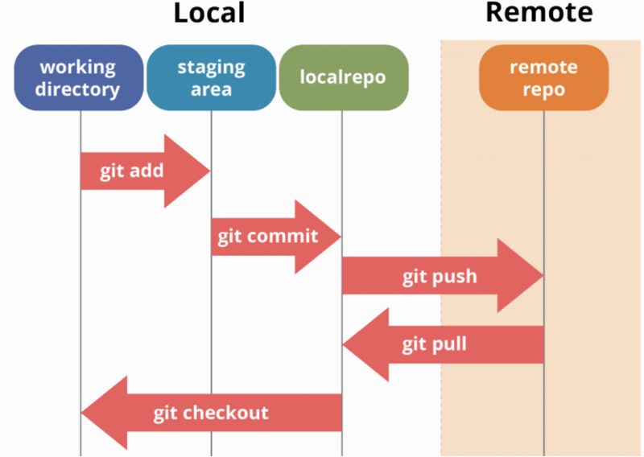

The Git workflow

## 2.3 What does/doesn’t go on GitHub?

### 2.3.1 What shouldn’t be on GitHub:

- Data files
- Patient identifiers
- Passwords/credentials
- Anything you don’t want other people to see

### 2.3.2 What should go on GitHub

- Periodic updates to files/repos you are currently working on.
- **.gitignore file!** - helps keep certain file types off of GitHub.

[figure not shown]

Example of a .gitignore file

## 2.4 Let’s create a GitHub account!

Creating a GitHub account: https://docs.github.com/en/get-started/start-your-journey/creating-an-account-on-github

# 3 GitKraken

- Helps simplify Git!
- It is free and there’s a desktop and web version of it. (I have only used the desktop version).
- Helps you visualize the changes made to each file before staging them!
- Although GitKraken allows you to edit files, PLEASE don’t use it for that purpose.
- GitKraken help documents - https://help.gitkraken.com/gitkraken-desktop/guide/

# 4 Github Cheat sheet

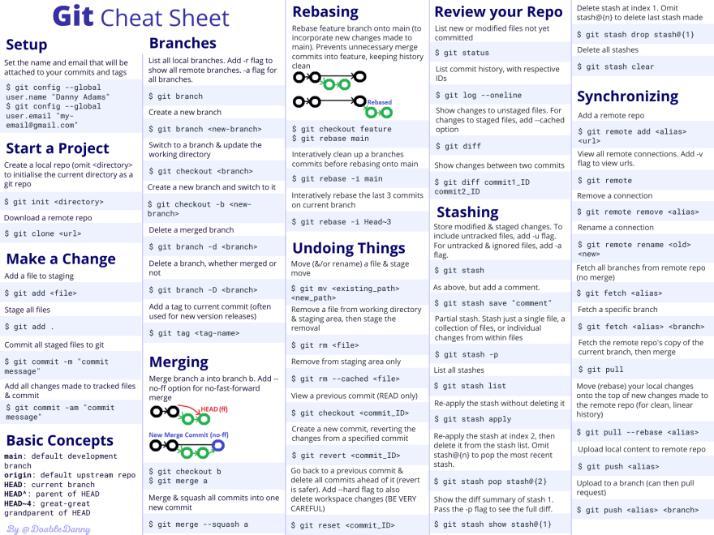

Git cheat sheet